# Dating App User Data

Isaac Baca

2023-02-28

## A visualization of one users experience with dating apps in 2022

This is a summary of data collected from a single users experience with online dating apps in the year 2022. The data set contains data on the following variables:

*The variable category **“me”** refers to the user. The variable category **“her”** refers to the match*

`Name`: The first name of the match.

`Year`: The year in which the match was made.

`Month`: The month in which the match was made.

`app`: A categorical variable indicating the app where the match was made. The categories for this variable include **bumble**, **tinder**, and **hinge**.

`age`: The age of the match.

`messaged_first`: A categorical variable indicating who messaged first after the match was made. The categories for this variable include **me**, **her**, or **none**.

`first_response`: A binary variable indicating whether the match replied at least one time after the conversation was initiated. The categories for this variable include **yes** or **no**.

`phone_number`: A binary variable indicating whether the phone numbers where exchanged between the user and the match. The categories for this variable include **yes** or **no**.

`first_date`: A binary variable indicating whether there was a first date. The categories for this variable include **yes** or **no**.

`date_duration`: A continuous variable indicating the duration of the date in minutes.

`enjoyment`: A variable from 1-10 indicating the users level of enjoyment of the first date, with 1 being the least enjoyable and 10 being the most enjoyable.

`cost`: A continuous variable indicating the total cost of the first date for both the user and the match.

`amount_me`: A continuous variable indicating the total cost of the first date for the user.

`amount_her`: A continuous variable indicating the total cost of the first date for the match.

`X2nd_date`: A binary variable indicating whether there was a second date. The categories for this variable include **yes** or **no**.

##### To begin, I load the libraries `readxl` to read in the data from excel, `dplyr` for data manipulation, and `ggplot2` for data visualization. I then import the data from excel into a data frame in r.

```r
library(readxl)
library(dplyr)
library(ggplot2)
exceldata = read_excel("/Volumes/Vandy Main/Data/Dating Apps/2022_Dating_App Data.xlsx")
data = data.frame(exceldata)
str(data)
```

```
## 'data.frame':    314 obs. of  18 variables:
##  $ Name          : chr  "Blanca" "Rheagan" "Wilza" "Mackenzie" ...
##  $ Year          : num  2022 2022 2022 2022 2022 ...
##  $ month         : chr  "NA" "NA" "NA" "NA" ...
##  $ app           : chr  "tinder" "tinder" "tinder" "tinder" ...
##  $ age           : chr  "NA" "NA" "NA" "NA" ...
##  $ messaged_first: chr  "me" "me" "none" "none" ...
##  $ first_response: chr  "yes" "yes" "NA" "NA" ...
##  $ phone_number  : chr  "no" "no" "no" "no" ...
##  $ date_cancled  : chr  "no" "no" "no" "no" ...
##  $ first_date    : chr  "no" "no" "no" "no" ...
##  $ date_duration : chr  "NA" "NA" "NA" "NA" ...
##  $ enjoyment     : chr  "NA" "NA" "NA" "NA" ...
##  $ paid          : chr  "NA" "NA" "NA" "NA" ...
##  $ cost          : chr  "NA" "NA" "NA" "NA" ...
##  $ amount_me     : chr  "NA" "NA" "NA" "NA" ...
##  $ amount_her    : chr  "NA" "NA" "NA" "NA" ...
##  $ X2nd_date     : chr  "NA" "NA" "NA" "NA" ...
##  $ relationship  : chr  "no" "no" "no" "no" ...
```

## Getting a count of who messaged first

I first group by `app`, then I get a count of each of the three categories in the `messaged_first` variable for each app. The possible categories include: **her**, **me**, or **none**.

```r
count_messaged_first = data %>%
  group_by(app) %>%
count(messaged_first)
count_messaged_first
```

```
## # A tibble: 8 × 3
## # Groups:   app [3]
##   app    messaged_first     n
##   <chr>  <chr>          <int>
## 1 bumble her               19
## 2 bumble none              23
## 3 hinge  her                7
## 4 hinge  me                96
## 5 hinge  none               4
## 6 tinder her                1
## 7 tinder me               160
## 8 tinder none               4
```

I then plot the results.

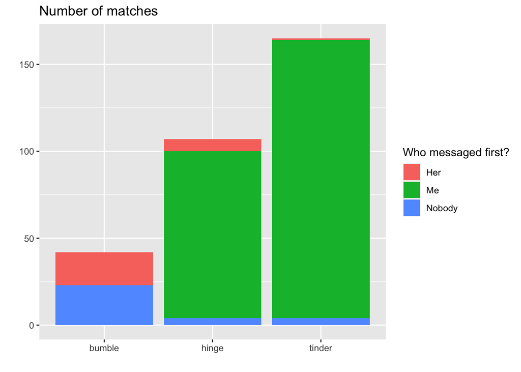

```r
ggplot(data, aes(x = app, fill = messaged_first)) + geom_bar() +
  labs(x =" ", y = " ", title = "Number of matches") +
  scale_fill_discrete(name = "Who messaged first?",
                      labels = c("Her", "Me", "Nobody"))
```

## Percent of matches who replied at least once

##### Of all of the conversations that were innitiated (by either party), I want to visualize the percentage of people who replied at least one time. This is the number of first responses divided by the total number of conversations innitiated for each `app`.

First, I obtain a count of the total conversations initiated by filtering the data for cases where either **me** or **her** is true for the `messaged_first` variable. Then I group by `app` and count the number of total conversations initiated for each `app`. I name this variable `conversation_initiated`.

```r
conversation_initiated = data %>%
  filter(messaged_first == "me" | messaged_first == "her") %>%
  group_by(app) %>%
  count()
conversation_initiated
```

```
## # A tibble: 3 × 2
## # Groups:   app [3]
##   app        n
##   <chr>  <int>
## 1 bumble    19
## 2 hinge    103
## 3 tinder   161
```

Next, I obtain a count of the number of people who replied at least once from each `app`, by filtering the data for all observations where **yes** is true for the `first_response` variable. Then, I group by `app` and count the number of first responses for each app. I name this variable `replied`.

```r
replied = data %>%
  filter(first_response == "yes") %>%
  group_by(app) %>%
  count()
replied
```

```
## # A tibble: 3 × 2
## # Groups:   app [3]
##   app        n
##   <chr>  <int>
## 1 bumble    12
## 2 hinge     76
## 3 tinder    85
```

Next, I bind together the `conversation_initiated` data frame with the *count vector* of the `replied` data frame. I name this new data frame `ratio`.

```r
ratio = cbind(conversation_initiated, replied$n)
ratio
```

```
## # A tibble: 3 × 3
## # Groups:   app [3]
##   app        n  ...3
##   <chr>  <int> <int>
## 1 bumble    19    12
## 2 hinge    103    76
## 3 tinder   161    85
```

I then rename the columns to reflect the data that they hold.

```r
ratio = ratio %>%
  rename("conversation_initiated" = "n", "replied" = "...3")
ratio
```

```
## # A tibble: 3 × 3
## # Groups:   app [3]
##   app    conversation_initiated replied
##   <chr>                   <int>   <int>
## 1 bumble                     19      12
## 2 hinge                     103      76
## 3 tinder                    161      85
```

Finally, I obtain the percentage of initiated conversations that received at least one reply from the match. I name this variable `percent_reply`, and add it to the `ratio` data frame.

```r
ratio = ratio %>%
  mutate(percent_reply = (replied/conversation_initiated) * 100)
ratio
```

```
## # A tibble: 3 × 4
## # Groups:   app [3]
##   app    conversation_initiated replied percent_reply
##   <chr>                   <int>   <int>         <dbl>
## 1 bumble                     19      12          63.2
## 2 hinge                     103      76          73.8
## 3 tinder                    161      85          52.8
```

Then I plot the results.

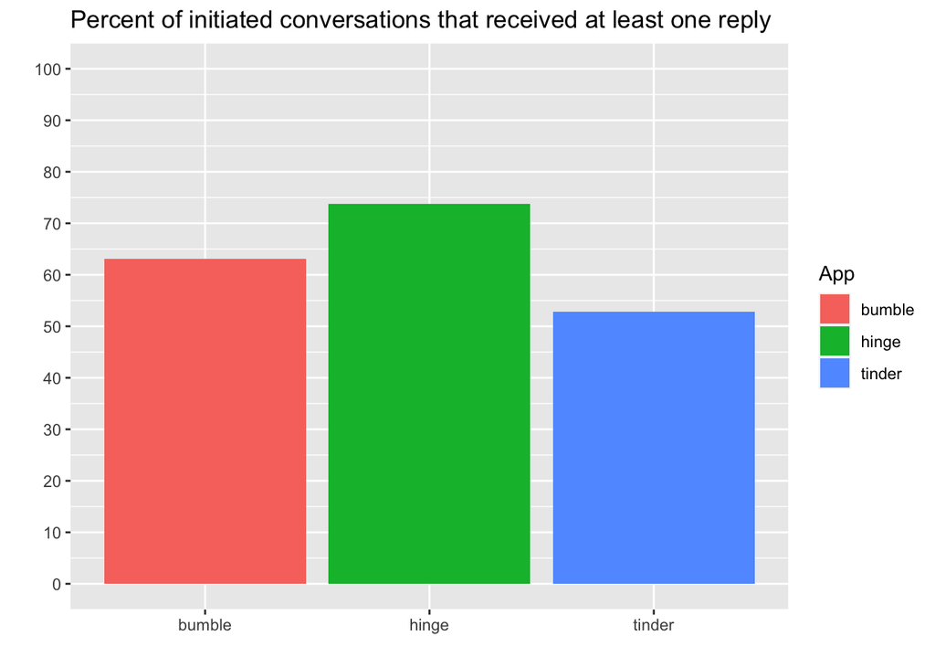

```r
ggplot(ratio, aes(x = app, y = percent_reply, fill = app)) + geom_col() +
  labs(title = "Percent of initiated conversations that received at least one reply", x =" ", y = " ") +
  scale_y_continuous(limits = c(0, 100), breaks = seq(0, 100, by = 10)) +
  scale_fill_discrete(name = "App")
```

## A count of phone numbers exchanged between the user and the match

First, I filter the data for all observations where **yes** is true for the variable `phone_number`. I name this new data frame `filtered_number`.

```r
filtered_number = data %>%
  filter(phone_number == "yes")
str(filtered_number)
```

```
## 'data.frame':    23 obs. of  18 variables:
##  $ Name          : chr  "Chels" "Teresa" "Thea" "Mon" ...
##  $ Year          : num  2022 2022 2022 2022 2022 ...
##  $ month         : chr  "NA" "NA" "NA" "NA" ...
##  $ app           : chr  "tinder" "tinder" "tinder" "tinder" ...
##  $ age           : chr  "NA" "NA" "NA" "NA" ...
##  $ messaged_first: chr  "me" "me" "me" "me" ...
##  $ first_response: chr  "yes" "yes" "yes" "yes" ...
##  $ phone_number  : chr  "yes" "yes" "yes" "yes" ...
##  $ date_cancled  : chr  "no" "no" "no" "no" ...
##  $ first_date    : chr  "no" "no" "no" "yes" ...
##  $ date_duration : chr  "NA" "NA" "NA" "NA" ...
##  $ enjoyment     : chr  "NA" "NA" "NA" "4" ...
##  $ paid          : chr  "NA" "NA" "NA" "free" ...
##  $ cost          : chr  "NA" "NA" "NA" "0" ...
##  $ amount_me     : chr  "NA" "NA" "NA" "0" ...
##  $ amount_her    : chr  "NA" "NA" "NA" "0" ...
##  $ X2nd_date     : chr  "NA" "NA" "NA" "no" ...
##  $ relationship  : chr  "no" "no" "no" "no" ...
```

Then, I plot the results.

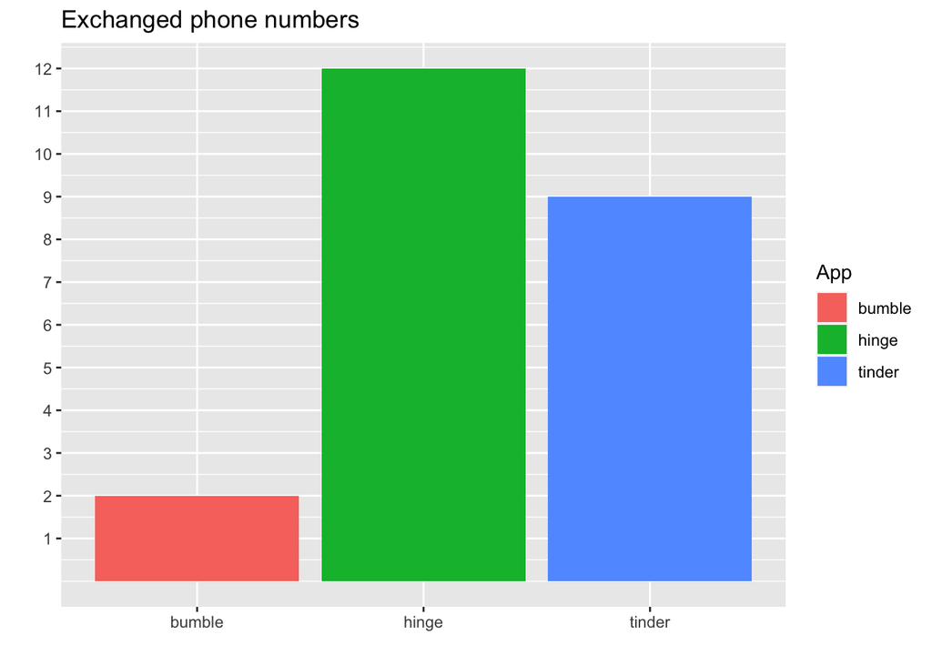

```r
ggplot(filtered_number, aes(x = app, fill = app)) + geom_bar() +
  labs(title = "Exchanged phone numbers", x =" ", y = " ") +
  scale_y_continuous(limits = c(0, 12), breaks = c(1:12)) +
  scale_fill_discrete(name = "App")
```

## A count of the amount of first dates that were canceled.

First, I filter the data for all observations where either **her** or **me** is true for the variable `date_cancled`. I name this new data frame `filtered_date_canceled`.

```r
filtered_data_canceled = data %>%
  filter(date_cancled == "her" | date_cancled == "me")
str(filtered_data_canceled)
```

```
## 'data.frame':    4 obs. of  18 variables:
##  $ Name          : chr  "Bianka" "Cam" "Denise" "Melissa"
##  $ Year          : num  2022 2022 2022 2022
##  $ month         : chr  "NA" "NA" "NA" "NA"
##  $ app           : chr  "tinder" "bumble" "hinge" "hinge"
##  $ age           : chr  "NA" "NA" "NA" "NA"
##  $ messaged_first: chr  "me" "her" "me" "me"
##  $ first_response: chr  "yes" "yes" "yes" "yes"
##  $ phone_number  : chr  "no" "yes" "yes" "yes"
##  $ date_cancled  : chr  "her" "her" "her" "her"
##  $ first_date    : chr  "no" "no" "no" "yes"
##  $ date_duration : chr  "NA" "NA" "NA" "NA"
##  $ enjoyment     : chr  "NA" "NA" "NA" "9"
##  $ paid          : chr  "NA" "NA" "NA" "both"
##  $ cost          : chr  "NA" "NA" "NA" "56"
##  $ amount_me     : chr  "NA" "NA" "NA" "28"
##  $ amount_her    : chr  "NA" "NA" "NA" "28"
##  $ X2nd_date     : chr  "NA" "NA" "NA" "yes"
##  $ relationship  : chr  "no" "no" "no" "pending"
```

Then, I plot the results.

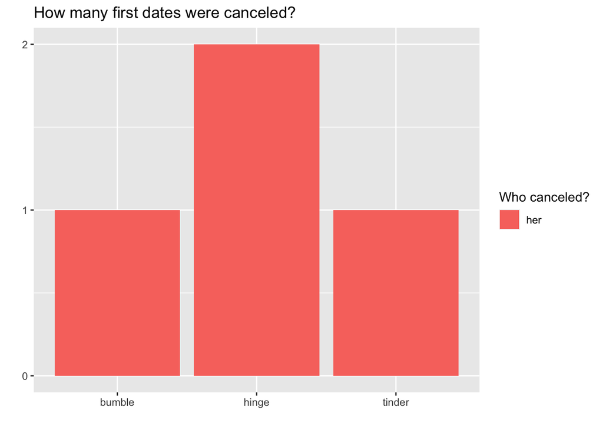

```r
ggplot(filtered_data_canceled, aes(x = app, fill = date_cancled)) + geom_bar() +
  labs(title = "How many first dates were canceled?", x = " ", y = " ") +
  scale_fill_discrete(name = "Who canceled?", labels = c("her")) +
  scale_y_continuous(breaks = c(0:2))
```

## A count of the amount of first and second dates that the user went on.

First, I filter the data for all observations where **yes** is true for the variable `first_date`. I name this new data frame `filtered_first_date`.

```r
filtered_first_date = data %>%
  filter(first_date == "yes")
str(filtered_first_date)
```

```
## 'data.frame':    13 obs. of  18 variables:
##  $ Name          : chr  "Mon" "Bri" "Kristal" "Chris" ...
##  $ Year          : num  2022 2022 2022 2022 2022 ...
##  $ month         : chr  "NA" "NA" "NA" "NA" ...
##  $ app           : chr  "tinder" "tinder" "bumble" "hinge" ...
##  $ age           : chr  "NA" "NA" "NA" "NA" ...
##  $ messaged_first: chr  "me" "me" "her" "me" ...
##  $ first_response: chr  "yes" "yes" "yes" "yes" ...
##  $ phone_number  : chr  "yes" "yes" "yes" "yes" ...
##  $ date_cancled  : chr  "no" "no" "no" "no" ...
##  $ first_date    : chr  "yes" "yes" "yes" "yes" ...
##  $ date_duration : chr  "NA" "NA" "NA" "NA" ...
##  $ enjoyment     : chr  "4" "10" "8" "1" ...
##  $ paid          : chr  "free" "both" "me" "me" ...
##  $ cost          : chr  "0" "350" "10.87" "30" ...
##  $ amount_me     : chr  "0" "100" "10.87" "30" ...
##  $ amount_her    : chr  "0" "250" "0" "0" ...
##  $ X2nd_date     : chr  "no" "no" "yes" "no" ...
##  $ relationship  : chr  "no" "no" "pending" "no" ...
```

Then, I plot the results.

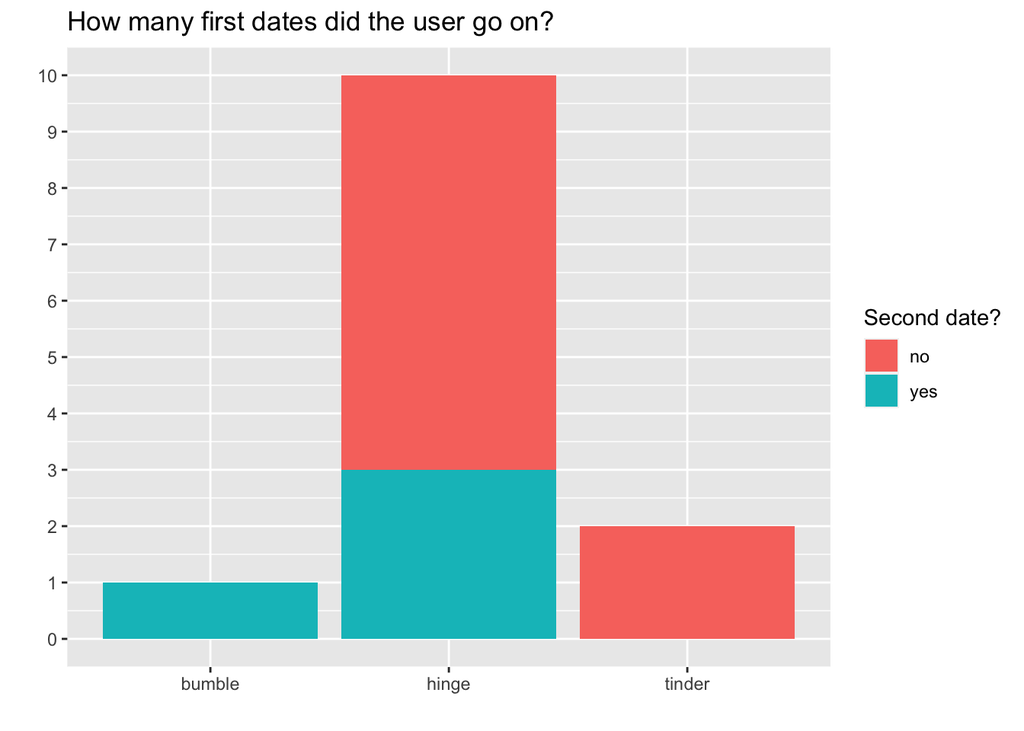

```r
ggplot(filtered_first_date, aes(x = app, fill = X2nd_date)) + geom_bar() +
  labs(title = "How many first dates did the user go on?", x = " ", y = " ") +
  scale_y_continuous(limits = c(0, 10), breaks = c(0:10)) +
  scale_fill_discrete(name = "Second date?")
```

## Who paid for the first date?

I use the `filtered_first_date` data frame created earlier and plot the results.

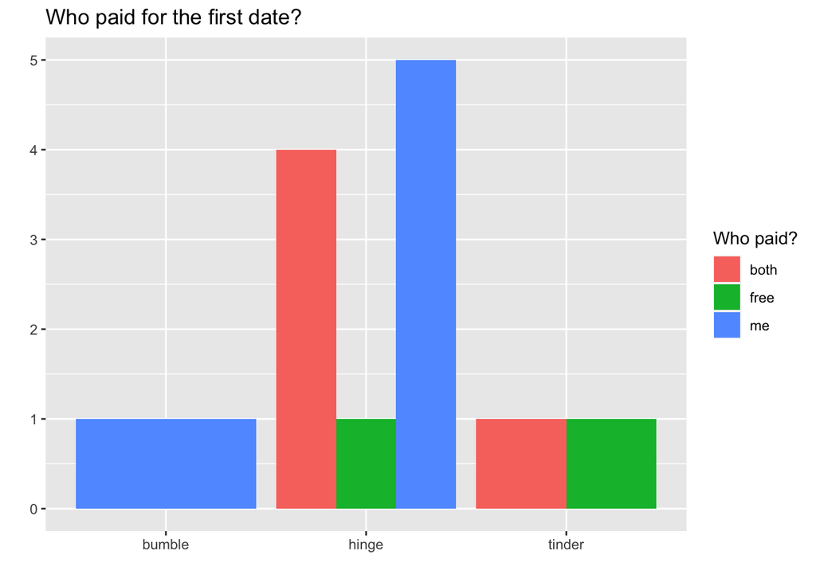

```r
ggplot(filtered_first_date, aes(x = app, fill = paid)) +
  geom_bar(position = "dodge") +
  labs(title = "Who paid for the first date?", x = " ", y = " ") +
  scale_y_continuous(limits = c(0, 5), breaks = c(0:5)) +
  scale_fill_discrete(name = "Who paid?")
```

## Cost of the first date

First, I use `as.numeric` to convert `cost` from a character into a numeric.

```r
filtered_first_date$cost = as.numeric(filtered_first_date$cost)
```

Then, I plot the results.

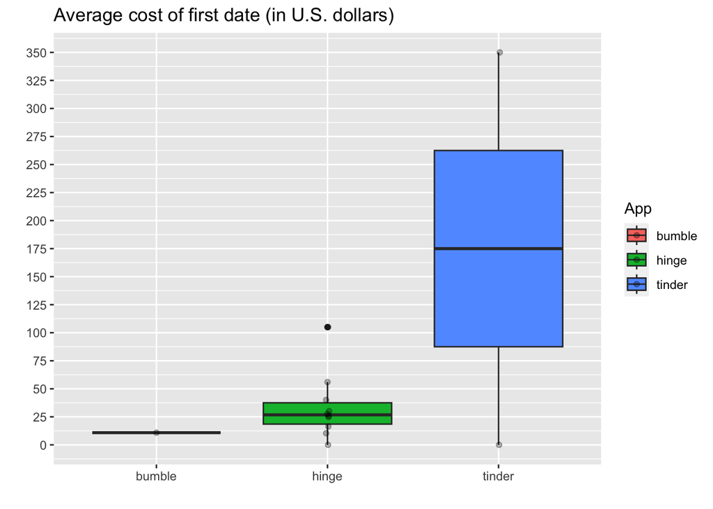

```r
ggplot(filtered_first_date, aes(x = app, y = cost, fill = app)) +
  geom_boxplot() +
  labs(title = "Average cost of first date (in U.S. dollars)", x = " ", y = " ") +
  scale_y_continuous(limits = c(0, 350), breaks = c(seq(0, 350, by = 25))) +
  scale_fill_discrete(name = "App") +
  geom_jitter(alpha = .3, width = .01, height = 0)
```

## Enjoyment of the first date (on a scale from 1-10)

First, I change the data type of `enjoyment` to numeric.

```r
filtered_first_date$enjoyment = as.numeric(filtered_first_date$enjoyment)
```

Then, I plot the results.

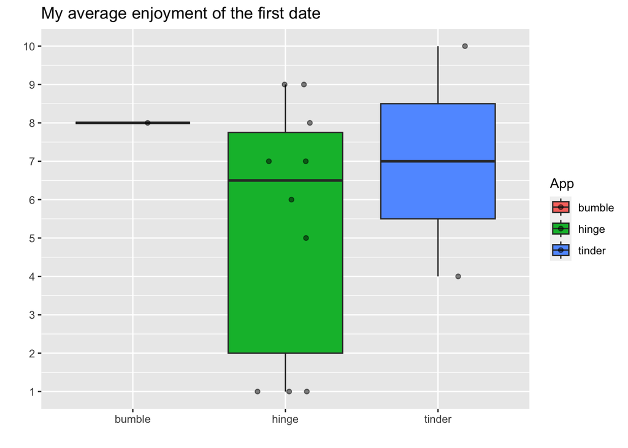

```r
ggplot(filtered_first_date, aes(x = app, y = enjoyment, fill = app)) +
  geom_boxplot() +
  labs(title = "My average enjoyment of the first date", x = " ", y = " ") +
  scale_y_continuous(limits = c(1, 10), breaks = c(seq(1, 10, by = 1))) +
  scale_fill_discrete(name = "App") +
  geom_jitter(alpha = .5, width = .2, height = 0)
```